# Evaluating Models

2020-12-07

In this segment, we will be looking at evaluating our models that we ran in the previous files. The models were fitted with training data (01-01-2018 to 30-06-2020) and tested on the same test data (01-07-2020 to 30-11-2020) so that we are able to compare their performance on unseen data.

```r
library(tidyverse)  # Data manipulation
library(tidymodels) # Building machine learning workflows and models
library(tidyquant)  # Functions for collecting and analyzing financial data
library(timetk)  # Functions to visualize, wrangle, and feature engineer time series data for forecasting and machine learning prediction
library(vip) # For constructing variable importance plots
library(caret) # Confusion matrix
```

# 1. Evaluating Models

In our previous files, we have built 3 different models for predicting when we should buy/sell bitcoin. We will introduce the buy-and-hold strategy to act as a benchmark performance for us. Here are the 4 models we will be evaluating:

Strategy 1: Buy and Hold  
Strategy 2: Using time series model - Prophet  
Strategy 3: Using XGBoost Trees  
Strategy 4: Using multiple models (ensemble)

# 2. Import predictions

Import predictions (on test data) from different models that we previously predicted

```r
# Time Series
# change to date format
prophet_predict <- read_csv("../data/prophet_signals_open.csv") %>%
  mutate(date = as.Date(date, format="%d/%m/%y")) %>%
  filter(between(date, as.Date("2020-07-01"), as.Date("2020-11-28")))

# XGBoost
xgb_predict <- read_csv("../data/xgboost_signals_open.csv") %>%
  filter(between(date, as.Date("2020-07-01"), as.Date("2020-11-28")))

# Ensemble
ensemble_predict <- read_csv("../data/ensemble_predict_open.csv") %>%
  mutate(date = as.Date(date, format="%d/%m/%y")) %>%
  filter(between(date, as.Date("2020-07-01"), as.Date("2020-11-28")))
```

# 3. Import Test Data

```r
# Read Data
bitcoin_price <- read_csv("../data/bitcoin_price.csv")
# Cleaning
bitcoin_price[bitcoin_price == 0] <- NA
bitcoin_price <- bitcoin_price %>%
  map_df(na.locf)

# Defining Target
# bitcoin_model <- bitcoin_price %>%
#   select(date, open, close) %>%
#   tq_mutate(select = close,
#             mutate_fun = periodReturn,
#             period = 'daily',
#             type = 'arithmetic',
#             col_rename = 'future_return') %>%
#   mutate(future_return_sign = as.factor(ifelse(future_return > 0, 1, 0))) %>%
#   # Shift up future_returns and sign by 1. Use today's data to predict tomorrow's returns.
#   # future_returns indicates the returns if I buy at today's close and sell at tmrrw's close
#   # each row represent today
#   mutate_at(c("future_return", "future_return_sign"), lead)
# bitcoin_model <- bitcoin_model[-nrow(bitcoin_model), ]

# Open to Open
bitcoin_model <- bitcoin_price %>%
  select(date, open, close) %>%
  tq_mutate(select = close,
            mutate_fun = periodReturn,
            period = 'daily',
            type = 'arithmetic',
            col_rename = "change") %>%
  rename(close_1d_change = change) %>%
  tq_mutate(select = open,
            mutate_fun = periodReturn,
            period = 'daily',
            type = 'arithmetic',
            col_rename = 'future_return') %>%
  mutate(future_return = lead(future_return, n=2, default = 0),
         future_return_sign = as.factor(ifelse(future_return > 0, 1, 0)))
bitcoin_model <- bitcoin_model[-nrow(bitcoin_model), ]

test <- bitcoin_model %>%
  # filter(between(date, as.Date("2020-07-01"), as.Date("2020-11-29")))
  filter(between(date, as.Date("2020-07-01"), as.Date("2020-11-28")))
```

# 3. Buy and Hold Strategy

Buy at the beginning and sell only towards the end

```r
# Base Model
# Combines all the assessment sets from the 12 splits from cross-validation resamples
base_model <- test %>%
  mutate(return_buyhold = cumprod(1 + future_return),
         signal_buyhold = 1)
```

# 4. Function to compute returns

```r
# Function to compute returns. Returns a 1 column returns vector
# Open to Open
computeReturns = function(base, data) {
  df = base %>%
    left_join(data, by="date") %>%
    mutate(Returns.Shift.Up = lead(future_return, default = 0),
         Returns = pred_class * Returns.Shift.Up,
         Cum.Returns = cumprod(1 + Returns)) %>%
    select(Cum.Returns)

  return(df$Cum.Returns)
}

# computeReturns <- function(base, predicted){
#   overall <- base %>%
#     left_join(predicted, by="date") %>%
#     mutate(trading_cost = abs(pred_class - lag(pred_class, n = 1, default = 0)) * 0.003,
#            return_model = cumprod(1 + future_return * pred_class - trading_cost))
#
#   return(overall$return_model)
# }
```

# 5. Compute returns of each model

```r
# Compute returns for all models and cbind them together
all_models <- base_model %>%
  mutate(signal_prophet = prophet_predict$pred_class,
         return_prophet = computeReturns(base_model, prophet_predict),
         signal_xgb = xgb_predict$pred_class,
         return_xgb = computeReturns(base_model, xgb_predict),
         signal_ensemble = ensemble_predict$pred_class,
         return_ensemble = computeReturns(base_model, ensemble_predict))

rmarkdown::paged_table(all_models %>% head())
```

| date | open | close | close_1d_change | future_return | future_return_sign | return_buyhold | signal_buyhold | signal_prophet | return_prophet | signal_xgb | return_xgb | signal_ensemble | return_ensemble |
| --- | --- | --- | --- | --- | --- | --- | --- | --- | --- | --- | --- | --- | --- |
| 2020-07-01 | 9136.89 | 9233.38 | 0.010995340 | -0.015089422 | 0 | 0.9849106 | 1 | 0 | 1.000000 | 1 | 0.9958413 | 1 | 0.9958413 |
| 2020-07-02 | 9230.97 | 9092.92 | -0.015212197 | -0.004158747 | 0 | 0.9808146 | 1 | 1 | 1.009752 | 1 | 1.0055523 | 1 | 1.0055523 |
| 2020-07-03 | 9091.68 | 9063.08 | -0.003281674 | 0.009751631 | 1 | 0.9903791 | 1 | 1 | 1.002575 | 1 | 0.9984051 | 1 | 0.9984051 |
| 2020-07-04 | 9053.87 | 9138.52 | 0.008323881 | -0.007107729 | 0 | 0.9833398 | 1 | 1 | 1.032365 | 1 | 1.0280718 | 1 | 1.0280718 |
| 2020-07-05 | 9142.16 | 9076.82 | -0.006751640 | 0.029714074 | 1 | 1.0125588 | 1 | 1 | 1.022459 | 0 | 1.0280718 | 1 | 1.0182068 |
| 2020-07-06 | 9077.18 | 9348.22 | 0.029900340 | -0.009595695 | 0 | 1.0028426 | 1 | 1 | 1.042842 | 0 | 1.0280718 | 0 | 1.0182068 |

# 6. Visualisations for buy/sell signal generated by the different models

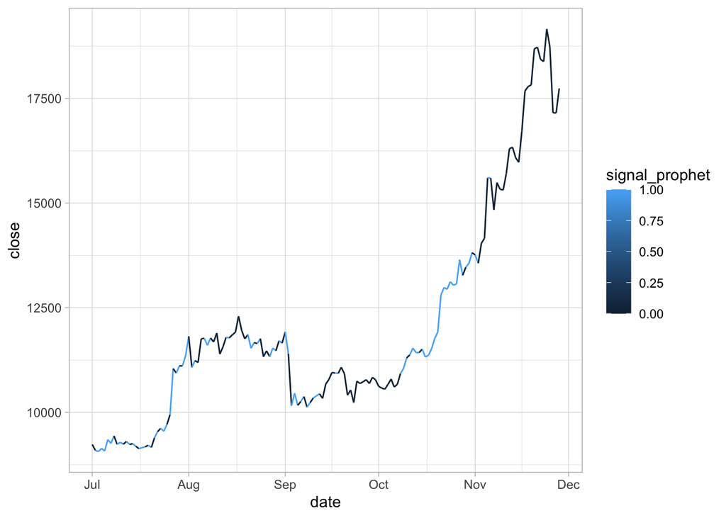

```r
# Plot predicted buy/sell signal on price data
# Plot for Prophet
all_models %>% ggplot(aes(x = date, y = close, color = signal_prophet)) +
    geom_line() +
    theme_light()
```

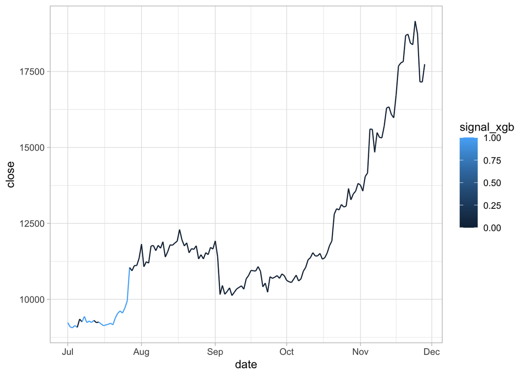

```r
# Plot for xgb
all_models %>% ggplot(aes(x = date, y = close, color = signal_xgb)) +
    geom_line() +
    theme_light()
```

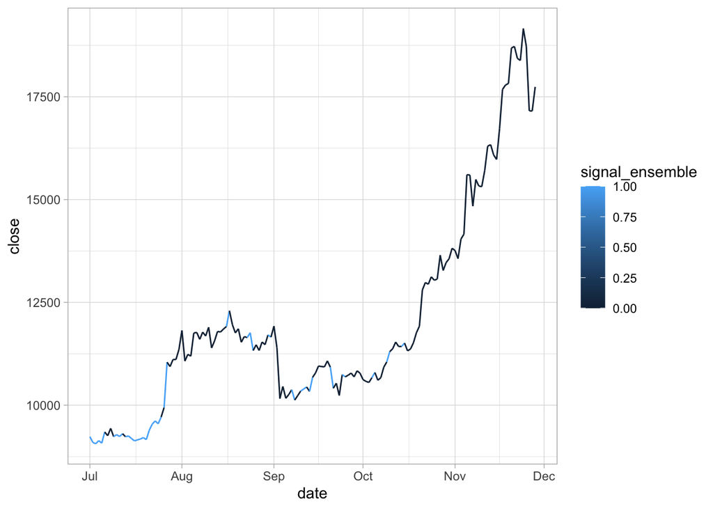

```r
# Plot for ensemble
all_models %>% ggplot(aes(x = date, y = close, color = signal_ensemble)) +
    geom_line() +
    theme_light()
```

# 7. Comparing returns across different models

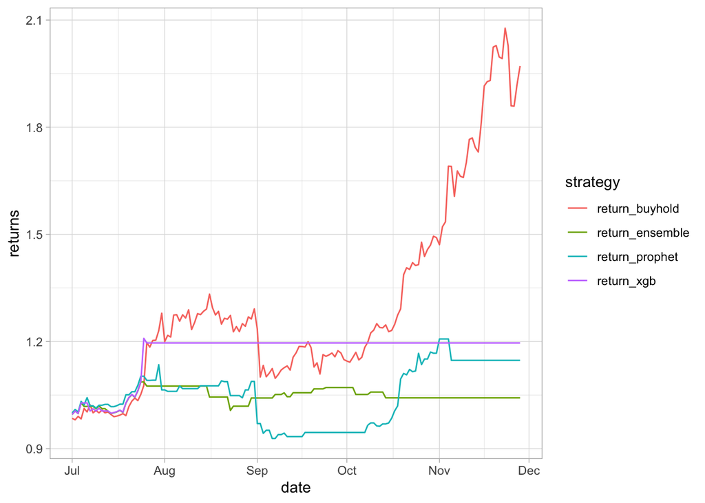

```r
all_models %>%
  select(date, return_buyhold, return_prophet, return_xgb, return_ensemble) %>%
  gather(key = "strategy", value = "returns", -date) %>%
  ggplot(aes(x=date, y = returns)) +
    geom_line(aes(color = strategy)) +
    theme_light()
```

# 8. Descriptive Statistics

## 8.1 Confusion Matrix

```r
# Confusion Matrix for Prohphet
print(confusionMatrix(factor(all_models$signal_prophet),
                factor(all_models$future_return_sign)))
```

```
# Confusion Matrix and Statistics
#
#           Reference
# Prediction  0  1
#          0 38 53
#          1 24 36
#
#                Accuracy : 0.4901
#                  95% CI : (0.4079, 0.5726)
#     No Information Rate : 0.5894
#     P-Value [Acc > NIR] : 0.994534
#
#                   Kappa : 0.0162
#
#  Mcnemar's Test P-Value : 0.001418
#
#             Sensitivity : 0.6129
#             Specificity : 0.4045
#          Pos Pred Value : 0.4176
#          Neg Pred Value : 0.6000
#              Prevalence : 0.4106
#          Detection Rate : 0.2517
#    Detection Prevalence : 0.6026
#       Balanced Accuracy : 0.5087
#
#        'Positive' Class : 0
#
```

```r
# Confusion Matrix for XGBoost
print(confusionMatrix(factor(all_models$signal_xgb),
                factor(all_models$future_return_sign)))
```

```
# Confusion Matrix and Statistics
#
#           Reference
# Prediction  0  1
#          0 53 76
#          1  9 13
#
#                Accuracy : 0.4371
#                  95% CI : (0.3566, 0.5201)
#     No Information Rate : 0.5894
#     P-Value [Acc > NIR] : 0.9999
#
#                   Kappa : 8e-04
#
#  Mcnemar's Test P-Value : 8.144e-13
#
#             Sensitivity : 0.8548
#             Specificity : 0.1461
#          Pos Pred Value : 0.4109
#          Neg Pred Value : 0.5909
#              Prevalence : 0.4106
#          Detection Rate : 0.3510
#    Detection Prevalence : 0.8543
#       Balanced Accuracy : 0.5005
#
#        'Positive' Class : 0
#
```

```r
# Confusion Matrix for Ensemble
print(confusionMatrix(factor(all_models$signal_ensemble),
                factor(all_models$future_return_sign)))
```

```
# Confusion Matrix and Statistics
#
#           Reference
# Prediction  0  1
#          0 49 68
#          1 13 21
#
#                Accuracy : 0.4636
#                  95% CI : (0.3822, 0.5465)
#     No Information Rate : 0.5894
#     P-Value [Acc > NIR] : 0.9993
#
#                   Kappa : 0.0232
#
#  Mcnemar's Test P-Value : 1.973e-09
#
#             Sensitivity : 0.7903
#             Specificity : 0.2360
#          Pos Pred Value : 0.4188
#          Neg Pred Value : 0.6176
#              Prevalence : 0.4106
#          Detection Rate : 0.3245
#    Detection Prevalence : 0.7748
#       Balanced Accuracy : 0.5131
#
#        'Positive' Class : 0
#
```

## 8.2 Overall Returns

Buy and hold strategy still generates the highest returns. This is probably because of the recent spike in prices from the large inflow of funds into cryptocurrency by institutions (eg. Paypal, Robinhood). This might be an event not well trained into the models as it is unseen data.

```r
all_returns <- all_models %>%
  select(date, return_buyhold, return_prophet, return_xgb, return_ensemble) %>%
  gather(key = "strategy", value = "returns", -date) %>%
  group_by(strategy) %>%
  summarise_all(last)

rmarkdown::paged_table(all_returns)
```

| strategy | date | returns |
| --- | --- | --- |
| return_buyhold | 2020-11-28 | 1.971272 |
| return_ensemble | 2020-11-28 | 1.042368 |
| return_prophet | 2020-11-28 | 1.147212 |
| return_xgb | 2020-11-28 | 1.195921 |

## 8.3 Mean Daily Returns and SD

```r
# Daily Returns
all_models_performance <- all_models %>%
  select(date, future_return, signal_buyhold, signal_prophet, signal_xgb, signal_ensemble) %>%
  gather(key = "strategy", value = "daily_returns", -c(date, future_return)) %>%
  mutate_at("daily_returns", ~.*future_return) %>%
  group_by(strategy) %>%
  summarise(d_ret = mean(daily_returns), d_sd = sd(daily_returns))

rmarkdown::paged_table(all_models_performance)
```

| strategy | d_ret | d_sd |
| --- | --- | --- |
| signal_buyhold | 0.004855881 | 0.02662365 |
| signal_ensemble | 0.001271589 | 0.01208932 |
| signal_prophet | 0.002894500 | 0.01478109 |
| signal_xgb | 0.001144899 | 0.01020259 |

## 8.4 Annualised Returns and SD

```r
all_models_performance <- all_models_performance %>%
  mutate(ann_ret = (1+d_ret)^365 - 1,
         ann_sd = d_sd * 365 ^ 0.5)

rmarkdown::paged_table(all_models_performance)
```

| strategy | d_ret | d_sd | ann_ret | ann_sd |
| --- | --- | --- | --- | --- |
| signal_buyhold | 0.004855881 | 0.02662365 | 4.8597516 | 0.5086441 |
| signal_ensemble | 0.001271589 | 0.01208932 | 0.5901609 | 0.2309661 |
| signal_prophet | 0.002894500 | 0.01478109 | 1.8718785 | 0.2823924 |
| signal_xgb | 0.001144899 | 0.01020259 | 0.5183879 | 0.1949202 |

## 8.5 Sharpe Ratio

Sharpe ratio us used to understand the return of an investment compared to its risk by computing the average return earned in excess of the risk-free rate per unit of volatility. In this case, we would use T-bills rate as the risk-free rate for computations. A model with higher sharpe ratio indicates a beter risk-adjusted performance and hence, in this case, apart from the buy-and-hold model, the time series (prophet) model is better compared to the other 2 models.

```r
all_models_performance <- all_models_performance %>%
  # Minus risk-free rate. T-bills
  mutate(ann_sharpe = ann_ret-0.0011/ann_sd)

rmarkdown::paged_table(all_models_performance)
```

| strategy | d_ret | d_sd | ann_ret | ann_sd | ann_sharpe |
| --- | --- | --- | --- | --- | --- |
| signal_buyhold | 0.004855881 | 0.02662365 | 4.8597516 | 0.5086441 | 4.8575890 |
| signal_ensemble | 0.001271589 | 0.01208932 | 0.5901609 | 0.2309661 | 0.5853983 |
| signal_prophet | 0.002894500 | 0.01478109 | 1.8718785 | 0.2823924 | 1.8679832 |
| signal_xgb | 0.001144899 | 0.01020259 | 0.5183879 | 0.1949202 | 0.5127446 |